# Introduction

Changes in oil prices have significant macroeconomic effects on countries and the global economy as a whole. The impact of oil price changes on macroeconomic variables depends on whether oil prices are rising or falling, and on the magnitude and persistence of the price change. Why does it have a significant impact?

Central banks may also respond to inflationary pressures from higher oil prices by adjusting interest rates. Changes in oil prices can affect exchange rates. Oil-exporting countries may see their currencies strengthen with higher oil prices, while oil-importing countries may see their currencies weaken.

Higher oil prices can act as a drag on economic growth, particularly for countries that are net oil importers, potentially slowing down economic activity. Countries that are net oil exporters can benefit from rising oil prices by earning more revenue from oil exports, thereby improving their trade balance.

There are voluntary, explicit decisions that change the price of oil and, on occasionally, exogenous events that cause a significant change in the price of oil.

Geopolitical events and oil supply disruptions can lead to sudden and significant oil price spikes, which can have unpredictable effects on macroeconomic stability and global security.

Economic models and analysis are often used to assess and predict the potential macroeconomic volatility associated with oil price fluctuations.

It is important to develop a time series model based on historical data and events in order to predict possible future scenarios and thus anticipate the necessary measures to be implemented. This will lead to greater economic and social stability.

## Questions

1. How has the distribution of total global oil production among the main oil-producing countries evolved over the past two decades?
2. Can we use time series models to predict future monthly oil prices and U.S. oil production based on past data?
3. What are the seasonal trends and patterns in monthly transportation services, and can time series models predict these variations?
4. How do changes in oil prices affect consumers’ attitudes and behaviors regarding personal transportation, including spending and saving decisions? How did the COVID Pandemic affected them?
5. How does the global oil price influence U.S. oil production? Is there an opposite relationship between them?
6. How have the US macroeconomic indicators, such as inflation rate and interest rates variation responded to oil price shocks and fluctuations in U.S. oil production over the past years?
7. How do fluctuations in oil prices and U.S oil production impact the Food Industry?
8. How do fluctuations in oil prices and U.S oil production impact the Healthcare Industry?
9. How can time series analysis of historical oil price data be used to develop short-term and long-term forecasts of oil price fluctuations?
10. How can time series analysis of historical U.S. oil production data be used to develop short-term and long-term forecasts of U.S. oil production fluctuations?

## Big Picture

Petroleum and its derivatives are an essential raw material in almost every manufacturing process. Since there are currently no substitutes available in sufficient quantities, their price is a determining factor in the cost structure of the final products. Therefore, any significant change in price has a direct impact on the real economy. This forces governments to make decisions to mitigate potential negative effects by adjusting public economic policies.

The cost dynamics of both the pharmaceutical and food industries are significantly impacted by oil prices, affecting various facets of their operations. Fluctuations in oil prices affect the cost of raw materials, particularly chemicals and plastics used in packaging, which can increase companies’ production costs as oil prices rise. In addition, higher oil prices contribute to increased transportation costs for shipping both raw materials and finished products, affecting the overall cost structure of the supply chain. Given the energy-intensive nature of pharmaceutical manufacturing, changes in oil prices can affect energy costs, thereby impacting operational expenses and potentially lead to higher production costs. Moreover, high oil prices can increase fuel costs, influencing consumers’ disposable income and, consequently, their spending patterns on food and pharmaceutical products. The complex relationship between oil prices and these industries is further shaped by factors such as geographic location, supply chain strategies and the nature of the product within the broader context of the interconnected global economy.

Higher oil prices increase production costs for businesses, potentially reducing their profit margins. This can lead to reduced business investment, particularly in energy-intensive industries.

As oil prices rise, consumers may reduce their spending on other goods and services due to higher energy costs. Consumer confidence may also be adversely affected, thereby affecting spending patterns.

Rising oil prices may encourage investment in the energy sector, including exploration and production. Conversely, falling oil prices may lead to reduced investment in the energy sector, affecting employment and economic activity in related industries.

### Big Picture Chart:

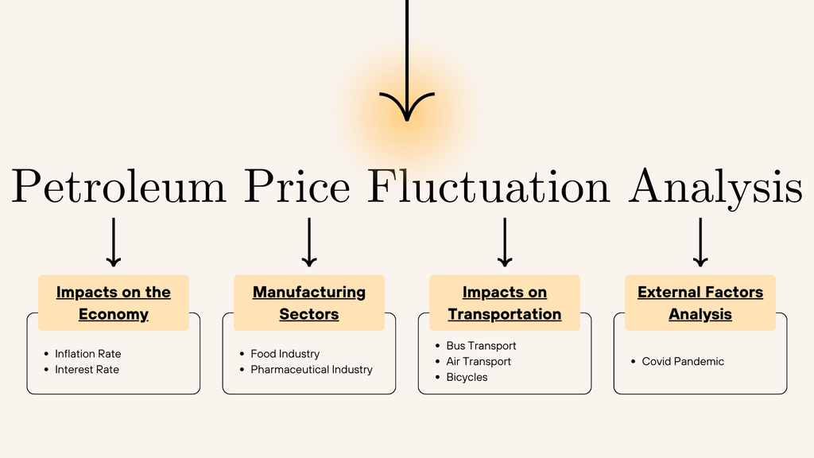

## Literature Review

A clear example of a voluntary decision is when OPEC (Organization of Petroleum Exporting Countries) decides to reduce the volume of production with the intention of causing an increase in the price of oil and its derivatives.

A geopolitical event, such as Russia’s invasion of Ukraine, where a unilateral decision by Russia not to supply oil and gas to the member countries of the European Union, creates a potential shortage, causing the price of oil to rise.

The current situation continues to put inflationary pressure on the US economy, forcing the government to monitor the inflation rate, continue the process of raising the interest rates, in order to strengthen its currency and make oil imports cheaper. In this context, the U.S. and the European Union are obliged to accelerate the process of replacing the use of fossil fuels with renewable, environmentally friendly energy, thus generating less dependence on oil.

[Go to next section: Data Sources](https://mazuckerberg.georgetown.domains/DSAN_5600/3_data_sources.html)